# 03 Prepare : Reading

## Objectives

- Introduction to OpenCV
- Loading, modifing and saving images

## Note to Students

The lesson material below contains sample code. **Please** code these code samples into a Python program on your computer and try each out so you understand it.

## OpenCV

### What is OpenCV

Computer Vision is continuing to be an important part of computer science. Below is the "about" section from opencv.org. We will be using the Python interface for this course.

About OpenCV

> OpenCV (Open Source Computer Vision Library) is an open source computer vision and machine learning software library. OpenCV was built to provide a common infrastructure for computer vision applications and to accelerate the use of machine perception in the commercial products. Being a BSD-licensed product, OpenCV makes it easy for businesses to utilize and modify the code.

> The library has more than 2500 optimized algorithms, which includes a comprehensive set of both classic and state-of-the-art computer vision and machine learning algorithms. These algorithms can be used to detect and recognize faces, identify objects, classify human actions in videos, track camera movements, track moving objects, extract 3D models of objects, produce 3D point clouds from stereo cameras, stitch images together to produce a high resolution image of an entire scene, find similar images from an image database, remove red eyes from images taken using flash, follow eye movements, recognize scenery and establish markers to overlay it with augmented reality, etc. OpenCV has more than 47 thousand people of user community and estimated number of downloads exceeding 14 million. The library is used extensively in companies, research groups and by governmental bodies.

> Along with well-established companies like Google, Yahoo, Microsoft, Intel, IBM, Sony, Honda, Toyota that employ the library, there are many startups such as Applied Minds, VideoSurf, and Zeitera, that make extensive use of OpenCV. OpenCV’s deployed uses span the range from stitching streetview images together, detecting intrusions in surveillance video in Israel, monitoring mine equipment in China, helping robots navigate and pick up objects at Willow Garage, detection of swimming pool drowning accidents in Europe, running interactive art in Spain and New York, checking runways for debris in Turkey, inspecting labels on products in factories around the world on to rapid face detection in Japan.

#### Installing OpenCV in VSCode

1. Start VSCode and open a Python file.
2. Click on the Menu item "Terminal" and click on "New Terminal".
3. For Window Users, type in the terminal: `pip install opencv-python`
4. For Mac Users, type in the terminal: `pip3 install opencv-python`

#### Where to get help on OpenCV

The main website for OpenCV is [link](https://opencv.org/). There are many examples both in Python and C++.

## loading images

Loading images from a file into OpenCV is done with the function imread(). The function imread() returns a NumPy array of pixels from the image file. Below are examples of using imread().

Note: This is the sample image that we will use for the rest of the lesson.

[figure not shown]

```python
# These are the packages that must be included for OpenCV
%matplotlib inline
import numpy as np
import cv2
from matplotlib import pyplot as plt
```

```python
# Read the image file and display it's contents
image = cv2.imread('tricycle.png')

# Display image in this document
plt.imshow(cv2.cvtColor(image, cv2.COLOR_BGR2RGB))
plt.show()
```

[output not shown]

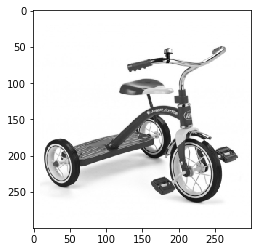

```python
# Read the image file and display it's contents as a Grayscale image
image_bw = cv2.imread('tricycle.png', 0)

# Display image in this document
plt.imshow(cv2.cvtColor(image_bw, cv2.COLOR_BGR2RGB))
plt.show()
```

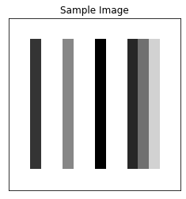

```
Shape = (16, 16)

[[255 255 255 255 255 255 255 255 255 255 255 255 255 255 255 255]
 [255 255 255 255 255 255 255 255 255 255 255 255 255 255 255 255]
 [255 255  76 255 255 149 255 255  29 255 255  64 128 215 255 255]
 [255 255  76 255 255 149 255 255  29 255 255  64 128 215 255 255]
 [255 255  76 255 255 149 255 255  29 255 255  64 128 215 255 255]
 [255 255  76 255 255 149 255 255  29 255 255  64 128 215 255 255]
 [255 255  76 255 255 149 255 255  29 255 255  64 128 215 255 255]
 [255 255  76 255 255 149 255 255  29 255 255  64 128 215 255 255]
 [255 255  76 255 255 149 255 255  29 255 255  64 128 215 255 255]
 [255 255  76 255 255 149 255 255  29 255 255  64 128 215 255 255]
 [255 255  76 255 255 149 255 255  29 255 255  64 128 215 255 255]
 [255 255  76 255 255 149 255 255  29 255 255  64 128 215 255 255]
 [255 255  76 255 255 149 255 255  29 255 255  64 128 215 255 255]
 [255 255  76 255 255 149 255 255  29 255 255  64 128 215 255 255]
 [255 255 255 255 255 255 255 255 255 255 255 255 255 255 255 255]
 [255 255 255 255 255 255 255 255 255 255 255 255 255 255 255 255]]
```

```python
# Load a small image image file as grayscale and display the pixels
# Notice that each pixel is a value from 0 to 255.
img = cv2.imread('rgbg.png', 0)

# Display the image
plt.imshow(img, cmap='gray')
plt.title('Sample Image'), plt.xticks([]), plt.yticks([])
plt.show()

# Load an color image in grayscale
print('Shape =', img.shape)
print()
print(img)
```

### Using the shape attribute

Image loaded into OpenCV will have 3 values (ie., (300, 400, 3))

- first value is the number of rows
- second value is the number of columns
- third value is the number of channels

A channel contains values for a color. In a RGB (Red, Green Blue) image, there are 3 channels. An 8-bit image would have 1 channels. Values in channels are from 0 to 255. They are of data type `np.uint8`.

```python
# Read the image file and display it's contents
print('The shape of the image =', image.shape)
```

```
The shape of the image = (300, 300, 3)
```

### Dividing channels from an image

You use the function OpenCV split() feature to divide channels. Note, that split() returns Blue, Green, Red in that order.

```python
blue, green, red = cv2.split(image)
print('shape of the blue channel =', blue.shape)
print('shape of the green channel =', green.shape)
print('shape of the red channel =', red.shape)
```

```
shape of the blue channel = (300, 300)
shape of the green channel = (300, 300)
shape of the red channel = (300, 300)
```

### Merging channels to create an image

```python
new_image = cv2.merge((blue, green, red))
print('Shape of new image =', new_image.shape)

# Display image in this document
plt.imshow(cv2.cvtColor(new_image, cv2.COLOR_BGR2RGB))
plt.show()
```

[output not shown]

```
Shape of new image = (300, 300, 3)
```

```
Shape of new image = (300, 300, 3)
```

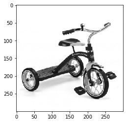

```python
# Creating a grayscale version of an image from the blue channel
new_image = cv2.merge((blue, blue, blue))
print('Shape of new image =', new_image.shape)

# Display image in this document
plt.imshow(cv2.cvtColor(new_image, cv2.COLOR_BGR2RGB))
plt.show()
```

## Modifing Images

This following section will use numpy to change image pixels. This is a warning from the OpenCV website:

> Numpy is an optimized library for fast array calculations. So simply accessing each and every pixel value and modifying it will be very slow and it is discouraged.

### Reading a pixel

Since an image in OpenCV is a numpy array, we can use `[]` to access pixels

```python
rows, cols, _ = image.shape
print(f'Image has {rows} rows and {cols} columns')

pixel = image[180, 100]
print('Pixel at (180, 100) =', pixel)
print('The type of the pixel is =', type(pixel))
```

```
Image has 300 rows and 300 columns
Pixel at (180, 100) = [ 84  85 205]
The type of the pixel is = <class 'numpy.ndarray'>
```

### Changing a pixel

```python
# Change pixel [180, 100]
# Note that something like "image[180, 100]" returns a NEW numpy array
pixel = image[180, 100]
print('Orginial Pixel at (180, 100) =', pixel)
pixel = [255, 255, 255]
print('Changed Pixel at (180, 100) =', pixel)
print('Pixel at image[180, 100] =', image[180, 100])
```

```
Orginial Pixel at (180, 100) = [ 84  85 205]
Changed Pixel at (180, 100) = [255, 255, 255]
Pixel at image[180, 100] = [ 84  85 205]
```

```python
# Change pixel [180, 100]
pixel = image[180, 100]
print('Orginial Pixel at (180, 100) =', pixel)
image[180, 100] = [255, 255, 255]
print('Pixel at image[180, 100] =', image[180, 100])
```

```
Orginial Pixel at (180, 100) = [ 84  85 205]
Pixel at image[180, 100] = [255 255 255]
```

### Changing multiple pixels

You can loop through a numpy array to change values, however, there is an easier method

```
Original Image
```

```
new image
```

[figure not shown]

```python
# Original Image
print('Original Image')
plt.imshow(cv2.cvtColor(image, cv2.COLOR_BGR2RGB))
plt.show()

# Copy the image for changes.  "new_image = image" will NOT work
new_image = image.copy()

print('new image')

# Change a small square 50 x 50 that starts a pixel [21, 34] to the color blue
# OpenCV are [Blue, Green, Red]
new_image[21:72, 34:85] = [255, 0, 0]

plt.imshow(cv2.cvtColor(new_image, cv2.COLOR_BGR2RGB))
plt.show()
```

[output not shown]

### Saving images

Saving images is easy with the function imwrite().

```python
# Read the image file and display it's contents
image = cv2.imread('tricycle.png')

# save image with filename 'temp.png'
cv2.imwrite('temp.png', image)

# Read the image file and display it's contents
image2 = cv2.imread('temp.png')

# Display image in this document
plt.imshow(cv2.cvtColor(image2, cv2.COLOR_BGR2RGB))
plt.show()
```

[output not shown]

### Creating images

Of course, you can create images using numpy. It is **very** important to create the numpy array with the correct data type. Images in OpenCV are of datatype uint8

```python
# Create an 8-bit 200 x 300 image
image = np.zeros((200, 300), dtype=np.uint8)
print('Shape =', image.shape)
```

```
Shape = (200, 300)
```

```python
# Create an 24-bit 200 x 300 image
image = np.zeros((200, 300, 3), dtype=np.uint8)
print('Shape =', image.shape)
```

```
Shape = (200, 300, 3)
```

### Drawing functions in OpenCV

We will be drawing onto images using the drawing functions from Opencv. [Link to the drawing functions documentation](https://docs.opencv.org/2.4/modules/core/doc/drawing_functions.html)

[figure not shown]

```python
# Open an image and draw a rectangle on it
# Read the image file and display it's contents
image = cv2.imread('tricycle.png')

color = (255, 0, 0)  # Blue, Green, Red
cv2.rectangle(image, (30, 30), (275, 110), color, thickness=1)

# Display image in this document
plt.imshow(cv2.cvtColor(image, cv2.COLOR_BGR2RGB))
plt.show()
```

```
Shape = (200, 300, 3)
```

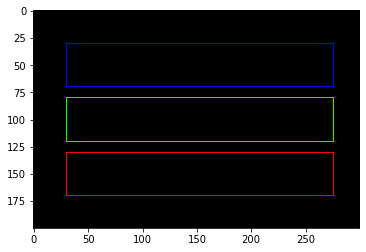

```python
# Create a numpy image array and draw on it
image = np.zeros((200, 300, 3), dtype=np.uint8)
print('Shape =', image.shape)

cv2.rectangle(image, (30, 30), (275, 70), color=(255, 0, 0), thickness=1)
cv2.rectangle(image, (30, 80), (275, 120), color=(0, 255, 0), thickness=1)
cv2.rectangle(image, (30, 130), (275, 170), color=(0, 0, 255), thickness=1)

# Display image in this document
plt.imshow(cv2.cvtColor(image, cv2.COLOR_BGR2RGB))
plt.show()
```